# Ejemplo de Análisis de Datos

# Ejemplo: Datos de nacimiento

Los siguientes datos corresponden a 427,323 registros con 13 variables de nacimientos de bebés en los Estados Unidos durante 2006[^1]. Mayor detalle sobre el pre-proceso de los datos se puede encontrar en el libro *R in a Nutshell*, p. 274.

```r
library(dplyr)
library(lattice)
library(tidyverse)
library(nutshell)     # paquete que contiene los datos
data(births2006.smpl) # datos de nacimiento
str(births2006.smpl)  # estructura de los datos
```

```
'data.frame':   427323 obs. of  13 variables:
 $ DOB_MM   : int  9 2 2 10 7 3 5 4 10 4 ...
 $ DOB_WK   : int  1 6 2 5 7 3 2 7 3 4 ...
 $ MAGER    : int  25 28 18 21 25 28 33 31 18 24 ...
 $ TBO_REC  : int  2 2 2 2 1 3 2 3 1 2 ...
 $ WTGAIN   : int  NA 26 25 6 36 35 26 25 46 43 ...
 $ SEX      : Factor w/ 2 levels "F","M": 1 2 1 2 2 2 2 1 1 2 ...
 $ APGAR5   : int  NA 9 9 9 10 8 9 9 9 9 ...
 $ DMEDUC   : Factor w/ 18 levels "1 year of college",..: 18 4 18 18 6 18 18 4 18 6 ...
 $ UPREVIS  : int  10 10 14 22 15 18 10 19 15 13 ...
 $ ESTGEST  : int  99 37 38 38 40 39 38 38 40 40 ...
 $ DMETH_REC: Factor w/ 3 levels "C-section","Unknown",..: 3 3 3 3 3 3 1 1 1 3 ...
 $ DPLURAL  : Factor w/ 5 levels "1 Single","2 Twin",..: 1 1 1 1 1 1 1 1 1 1 ...
 $ DBWT     : int  3800 3625 3650 3045 3827 3090 3430 3204 3227 3459 ...
```

```r
head(births2006.smpl) # Primeros renglones. Se pueden ver los últimos con tail
```

```
        DOB_MM DOB_WK MAGER TBO_REC WTGAIN SEX APGAR5                 DMEDUC UPREVIS ESTGEST
591430       9      1    25       2     NA   F     NA                   NULL      10      99
1827276      2      6    28       2     26   M      9     2 years of college      10      37
1705673      2      2    18       2     25   F      9                   NULL      14      38
3368269     10      5    21       2      6   M      9                   NULL      22      38
2990253      7      7    25       1     36   M     10 2 years of high school      15      40
966967       3      3    28       3     35   M      8                   NULL      18      39
        DMETH_REC  DPLURAL DBWT
591430    Vaginal 1 Single 3800
1827276   Vaginal 1 Single 3625
1705673   Vaginal 1 Single 3650
3368269   Vaginal 1 Single 3045
2990253   Vaginal 1 Single 3827
966967    Vaginal 1 Single 3090
```

La descripción de los variables disponibles conforman el *diccionario de datos* que usualmente contiene los *metadatos* que describen las características relevantes de los datos.

- `DOB_MM`: mes de la fecha de nacimiento 1-12
- `DOB_WK`: dia de la semana de la fecha de nacimiento 1-7, 1 es para domingo y así sucesivamente.
- `MAGER`: edad de la madre N
- `TBO\_REC`: orden de nacimiento total. N(1)
- `WTGAIN`: peso ganado de la madre en kg N
- `SEX`: sexo del bebé C(1)
- `APGAR5`: score Apgar 0-10
- `DMEDUC`: Nivel educativo de la madre C
- `UPREVIS`: Número de visitas prenatales: cuántas veces visitó a ginecóloga. N
- `ESTGEST`: semanas de gestación estimadas N
- `DMETH\_REC`: Método de nacimiento C
- `DPLURAL`: Nacimientos múltiples (único, gemelos, triátes, etc.) C
- `DBWTH`: Peso al nacer (en gramos) N

Para realizar nuestro análisis, podemos separar los datos cuantitativos de los categóricos y éstos últimos utilizarlos como *etiquetas* para analizar la información por grupos. La matriz $X$ se conforma con todas las variables, convirtiendo a factores las variables categóricas.

## Algunas preguntas relevantes sobre los datos

Todo análisis comienza intentando responder algunas preguntas básicas que podamos responder obteniendo algunas estadísticas descriptivas de la información. Por ejemplo:

- ¿Cómo se distribuyen las variables? ¿Hay datos faltantes?
- ¿Cuál es el peso promedio de los bebés al nacimiento?
- ¿Hay alguna relación entre la edad de la madre o su peso y el peso de los bebés, o los nacimientos múltiples?
- ¿Hay alguna relación entre la edad de la madre al momento del nacimiento y su nivel de escolaridad?
- ¿cuál es el periodo promedio de gestación y cuál es su desviación estándar?
- ¿En qué meses nacen más bebés? ¿Cómo se distribuye el número de nacimientos por mes? ¿por día de la semana?
- ¿Hay alguna relación entre la edad de la madre o su edad y el score Apgar del bebé?
- ¿Se puede predecir el peso del bebé de características como el periodo estimado de gestación y la ganancia en peso de la madre?
- ¿Podemos identificar nacimientos que llevan a un score APGAR bajo? Por ejemplo, ¿la edad de la madre es un factor de riesgo?

En las siguientes secciones se responderán algunas de estas preguntas, y utilizaremos las herramientas de resumen numéricos y de visualización:

- Análisis univariado para cada variable.
- Medidas multivariadas de centralidad.
- Medidas multivariadas de dispersión.
- Gráficas univariadas
- Gráficas multivariadas

### Análisis general

#### Estadísticas sumarias

Lo primero que podemos hacer es intentar conocer las variables que conforman la base de datos disponible. Podemos ver un resumen general de las variables. ¿Qué tipos de variables tenemos? ¿Cuáles son continuas, discretas, nominales, ordinales? ¿Qué variables tienen datos faltantes? ¿Cuántos casos tienen datos completos?

```r
summary(births2006.smpl)
```

```
     DOB_MM           DOB_WK          MAGER          TBO_REC          WTGAIN      SEX
 Min.   : 1.000   Min.   :1.000   Min.   :12.00   Min.   :1.000   Min.   : 0.00   F:208653
 1st Qu.: 4.000   1st Qu.:3.000   1st Qu.:23.00   1st Qu.:1.000   1st Qu.:21.00   M:218670
 Median : 7.000   Median :4.000   Median :27.00   Median :2.000   Median :30.00
 Mean   : 6.601   Mean   :4.065   Mean   :27.37   Mean   :2.415   Mean   :30.83
 3rd Qu.:10.000   3rd Qu.:6.000   3rd Qu.:32.00   3rd Qu.:3.000   3rd Qu.:40.00
 Max.   :12.000   Max.   :7.000   Max.   :50.00   Max.   :8.000   Max.   :98.00
                                                  NA's   :3134    NA's   :75856
     APGAR5                         DMEDUC          UPREVIS         ESTGEST         DMETH_REC
 Min.   : 0.00   NULL                  :211059   Min.   : 0.00   Min.   :12.0   C-section:132068
 1st Qu.: 9.00   2 years of high school: 65462   1st Qu.: 9.00   1st Qu.:38.0   Unknown  :  1517
 Median : 9.00   2 years of college    : 36713   Median :12.00   Median :39.0   Vaginal  :293738
 Mean   : 8.86   3 years of college    : 24600   Mean   :13.96   Mean   :46.6
 3rd Qu.: 9.00   4 years of high school: 23863   3rd Qu.:14.00   3rd Qu.:40.0
 Max.   :10.00   3 years of high school: 15942   Max.   :99.00   Max.   :99.0
 NA's   :58231   (Other)               : 49684
                   DPLURAL            DBWT
 1 Single              :412979   Min.   : 227
 2 Twin                : 13658   1st Qu.:2972
 3 Triplet             :   642   Median :3310
 4 Quadruplet          :    39   Mean   :3265
 5 Quintuplet or higher:     5   3rd Qu.:3629
                                 Max.   :8165
                                 NA's   :434
```

De los resultados mostrados, podemos ver que algunas variables tienen datos faltantes.

Otra opción es usar el paquete `skimr` que se integra a la forma de trabajo con `tidyverse`:

```r
library(skimr)
births2006.smpl %>% skim() # o skim(births2006.smpl)
```

Data summary

| Name | Piped data |
| --- | --- |
| Number of rows | 427323 |
| Number of columns | 13 |
| _______________________ |  |
| Column type frequency: |  |
| factor | 4 |
| numeric | 9 |
| ________________________ |  |
| Group variables | None |

**Variable type: factor**

| skim_variable | n_missing | complete_rate | ordered | n_unique | top_counts |
| --- | --- | --- | --- | --- | --- |
| SEX | 0 | 1 | FALSE | 2 | M: 218670, F: 208653 |
| DMEDUC | 0 | 1 | FALSE | 18 | NUL: 211059, 2 y: 65462, 2 y: 36713, 3 y: 24600 |
| DMETH_REC | 0 | 1 | FALSE | 3 | Vag: 293738, C-s: 132068, Unk: 1517 |
| DPLURAL | 0 | 1 | FALSE | 5 | 1 S: 412979, 2 T: 13658, 3 T: 642, 4 Q: 39 |

**Variable type: numeric**

| skim_variable | n_missing | complete_rate | mean | sd | p0 | p25 | p50 | p75 | p100 | hist |
| --- | --- | --- | --- | --- | --- | --- | --- | --- | --- | --- |
| DOB_MM | 0 | 1.00 | 6.60 | 3.42 | 1 | 4 | 7 | 10 | 12 | ▇▅▆▆▇ |
| DOB_WK | 0 | 1.00 | 4.07 | 1.83 | 1 | 3 | 4 | 6 | 7 | ▇▅▅▅▇ |
| MAGER | 0 | 1.00 | 27.37 | 6.16 | 12 | 23 | 27 | 32 | 50 | ▂▇▆▂▁ |
| TBO_REC | 3134 | 0.99 | 2.41 | 1.51 | 1 | 1 | 2 | 3 | 8 | ▇▂▂▁▁ |
| WTGAIN | 75856 | 0.82 | 30.83 | 14.45 | 0 | 21 | 30 | 40 | 98 | ▂▇▃▁▁ |
| APGAR5 | 58231 | 0.86 | 8.86 | 0.77 | 0 | 9 | 9 | 9 | 10 | ▁▁▁▁▇ |
| UPREVIS | 0 | 1.00 | 13.96 | 15.86 | 0 | 9 | 12 | 14 | 99 | ▇▁▁▁▁ |
| ESTGEST | 0 | 1.00 | 46.60 | 20.80 | 12 | 38 | 39 | 40 | 99 | ▁▇▁▁▁ |
| DBWT | 434 | 1.00 | 3264.67 | 595.24 | 227 | 2972 | 3310 | 3629 | 8165 | ▁▇▆▁▁ |

También se puede agrupar por alguna de las variables categóricas y usarla para obtener resúmenes condicionales de las variables:

```r
births2006.smpl %>%
     group_by(SEX) %>%
     skim()
```

Data summary

| Name | Piped data |
| --- | --- |
| Number of rows | 427323 |
| Number of columns | 13 |
| _______________________ |  |
| Column type frequency: |  |
| factor | 3 |
| numeric | 9 |
| ________________________ |  |
| Group variables | SEX |

**Variable type: factor**

| skim_variable | SEX | n_missing | complete_rate | ordered | n_unique | top_counts |
| --- | --- | --- | --- | --- | --- | --- |
| DMEDUC | F | 0 | 1 | FALSE | 18 | NUL: 102935, 2 y: 32013, 2 y: 17974, 3 y: 11992 |
| DMEDUC | M | 0 | 1 | FALSE | 18 | NUL: 108124, 2 y: 33449, 2 y: 18739, 3 y: 12608 |
| DMETH_REC | F | 0 | 1 | FALSE | 3 | Vag: 145633, C-s: 62327, Unk: 693 |
| DMETH_REC | M | 0 | 1 | FALSE | 3 | Vag: 148105, C-s: 69741, Unk: 824 |
| DPLURAL | F | 0 | 1 | FALSE | 5 | 1 S: 201596, 2 T: 6709, 3 T: 327, 4 Q: 18 |
| DPLURAL | M | 0 | 1 | FALSE | 5 | 1 S: 211383, 2 T: 6949, 3 T: 315, 4 Q: 21 |

**Variable type: numeric**

| skim_variable | SEX | n_missing | complete_rate | mean | sd | p0 | p25 | p50 | p75 | p100 | hist |
| --- | --- | --- | --- | --- | --- | --- | --- | --- | --- | --- | --- |
| DOB_MM | F | 0 | 1.00 | 6.60 | 3.42 | 1 | 4 | 7 | 10 | 12 | ▇▅▆▆▇ |
| DOB_MM | M | 0 | 1.00 | 6.61 | 3.42 | 1 | 4 | 7 | 10 | 12 | ▇▅▆▆▇ |
| DOB_WK | F | 0 | 1.00 | 4.06 | 1.83 | 1 | 3 | 4 | 6 | 7 | ▇▅▅▅▇ |
| DOB_WK | M | 0 | 1.00 | 4.07 | 1.83 | 1 | 3 | 4 | 6 | 7 | ▇▅▅▅▇ |
| MAGER | F | 0 | 1.00 | 27.39 | 6.17 | 12 | 23 | 27 | 32 | 50 | ▂▇▆▂▁ |
| MAGER | M | 0 | 1.00 | 27.36 | 6.16 | 12 | 22 | 27 | 32 | 50 | ▂▇▆▂▁ |
| TBO_REC | F | 1521 | 0.99 | 2.42 | 1.51 | 1 | 1 | 2 | 3 | 8 | ▇▂▂▁▁ |
| TBO_REC | M | 1613 | 0.99 | 2.41 | 1.51 | 1 | 1 | 2 | 3 | 8 | ▇▂▂▁▁ |
| WTGAIN | F | 37024 | 0.82 | 30.45 | 14.36 | 0 | 21 | 30 | 39 | 98 | ▃▇▃▁▁ |
| WTGAIN | M | 38832 | 0.82 | 31.20 | 14.53 | 0 | 22 | 30 | 40 | 98 | ▂▇▃▁▁ |
| APGAR5 | F | 28398 | 0.86 | 8.87 | 0.75 | 0 | 9 | 9 | 9 | 10 | ▁▁▁▁▇ |
| APGAR5 | M | 29833 | 0.86 | 8.85 | 0.79 | 0 | 9 | 9 | 9 | 10 | ▁▁▁▁▇ |
| UPREVIS | F | 0 | 1.00 | 14.02 | 15.93 | 0 | 9 | 12 | 14 | 99 | ▇▁▁▁▁ |
| UPREVIS | M | 0 | 1.00 | 13.91 | 15.79 | 0 | 9 | 12 | 14 | 99 | ▇▁▁▁▁ |
| ESTGEST | F | 0 | 1.00 | 46.63 | 20.79 | 15 | 38 | 39 | 40 | 99 | ▁▇▁▁▁ |
| ESTGEST | M | 0 | 1.00 | 46.58 | 20.81 | 12 | 38 | 39 | 40 | 99 | ▁▇▁▁▁ |
| DBWT | F | 202 | 1.00 | 3208.80 | 578.78 | 227 | 2920 | 3255 | 3572 | 8165 | ▁▇▅▁▁ |
| DBWT | M | 232 | 1.00 | 3317.99 | 605.75 | 227 | 3015 | 3365 | 3686 | 8165 | ▁▇▇▁▁ |

Otro paquete útil para resúmenes numéricos. Esta tiene la ventaja de incluir algunas medidas adicionales y algunas estadísticas robustas, como la mediana, la media recortada, la diferencia media absoluta, etc:

```r
library(psych)
describe(births2006.smpl, check = F)  # También hay opción describe.by para grupos.
```

```
Converted non-numeric matrix input to numeric.  Are you sure you wanted to do this. Please check your data
```

```
           vars      n    mean     sd median trimmed    mad min  max range  skew kurtosis   se
DOB_MM*       1 427323    6.60   3.42      7    6.62   4.45   1   12    11 -0.05    -1.19 0.01
DOB_WK*       2 427323    4.07   1.83      4    4.07   2.97   1    7     6 -0.03    -1.10 0.00
MAGER*        3 427323   27.37   6.16     27   27.19   7.41  12   50    38  0.25    -0.59 0.01
TBO_REC*      4 424189    2.41   1.51      2    2.17   1.48   1    8     7  1.35     1.88 0.00
WTGAIN*       5 351467   30.83  14.45     30   30.36  13.34   0   98    98  0.51     1.10 0.02
SEX*          6 427323     NaN     NA     NA     NaN     NA Inf -Inf  -Inf    NA       NA   NA
APGAR5*       7 369092    8.86   0.77      9    8.98   0.00   0   10    10 -5.59    46.19 0.00
DMEDUC*       8 427323     NaN     NA     NA     NaN     NA Inf -Inf  -Inf    NA       NA   NA
UPREVIS*      9 427323   13.96  15.86     12   11.39   2.97   0   99    99  4.84    23.15 0.02
ESTGEST*     10 427323   46.60  20.80     39   41.63   1.48  12   99    87  2.09     2.47 0.03
DMETH_REC*   11 427323     NaN     NA     NA     NaN     NA Inf -Inf  -Inf    NA       NA   NA
DPLURAL*     12 427323     NaN     NA     NA     NaN     NA Inf -Inf  -Inf    NA       NA   NA
DBWT*        13 426889 3264.67 595.24   3310 3297.92 493.71 227 8165  7938 -0.90     2.88 0.91
```

Para variables categóricas o discretas, podemos ver los diferentes valores que toma un factor, o los valores que toma una variable finita:

```r
levels(births2006.smpl$DMEDUC)  # Niveles de un factor (valores únicos)
```

```
 [1] "1 year of college"            "1 year of high school"        "1 Years of elementary school"
 [4] "2 years of college"           "2 Years of elementary school" "2 years of high school"
 [7] "3 years of college"           "3 Years of elementary school" "3 years of high school"
[10] "4 Years of elementary school" "4 years of high school"       "5 Years of elementary school"
[13] "6 Years of elementary school" "7 Years of elementary school" "8 Years of elementary school"
[16] "No formal education"          "Not on certificate"           "NULL"
```

```r
unique(births2006.smpl$APGAR5)  # Valores únicos de una variable discreta
```

```
 [1] NA  9 10  8  1  7  0  2  5  6  4  3
```

#### Distribuciones univariadas

Podemos considerar distribuciones univariadas como la del peso de todos los bebés, o bien, considerar algunas distribuciones condicionales de interés. Por ejemplo, podemos comparar la distribución de los varones y niñas al nacer usando densidades o histogramas, o condicionar el peso del bebé con respecto a los nacimientos múltiples por ejemplo.

```r
summary(births2006.smpl$DBWT/1000) # Convertimos el peso a kilos para facilitar su lectura
```

```
   Min. 1st Qu.  Median    Mean 3rd Qu.    Max.    NA's
  0.227   2.972   3.310   3.265   3.629   8.165     434
```

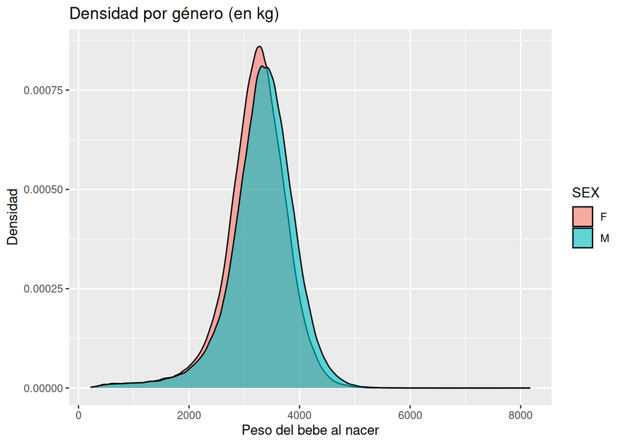

```r
# Usando ggplot
p <- births2006.smpl %>%
        group_by(SEX) %>%
        select(DBWT,SEX) %>%
        ggplot(aes(x = DBWT, fill = SEX)) +
          geom_density(alpha = 0.6) +
          labs(title = "Densidad por género (en kg)",
               x = "Peso del bebe al nacer",
               y = "Densidad")

print(p)
```

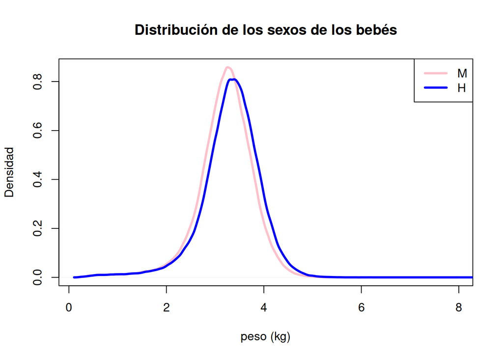

```r
# Usando base
with(births2006.smpl[complete.cases(births2006.smpl),],
     {
     plot(density(DBWT[SEX == "F"]/1000), xlab = "", ylab = "", col = "pink", main = "", lwd = 3)
     lines(density(DBWT[SEX == "M"]/1000), col = "blue", lwd =3)
     })
# Agrega una leyenda para distinguir las líneas
legend("topright", legend = c("M","H"), col = c("pink","blue"), lwd = c(3,3))
title(main = "Distribución de los sexos de los bebés", xlab = "peso (kg)", ylab = "Densidad")
```

Otra versión con histogramas en `ggplot2`:

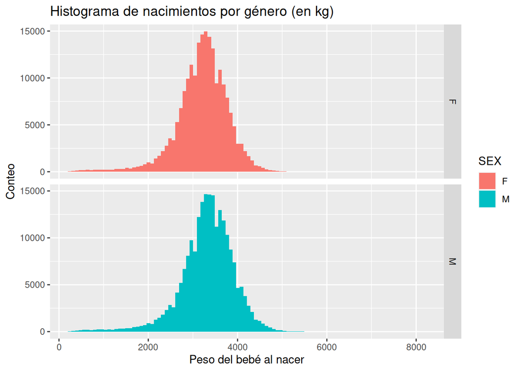

```r
ggplot(data =  births2006.smpl, aes(DBWT, geom = "density", fill = SEX)) +
       geom_histogram(bins = 100) +
       facet_grid(SEX~.) +
labs(title="Histograma de nacimientos por género (en kg)",
      y = "Conteo",
      x = "Peso del bebé al nacer")
```

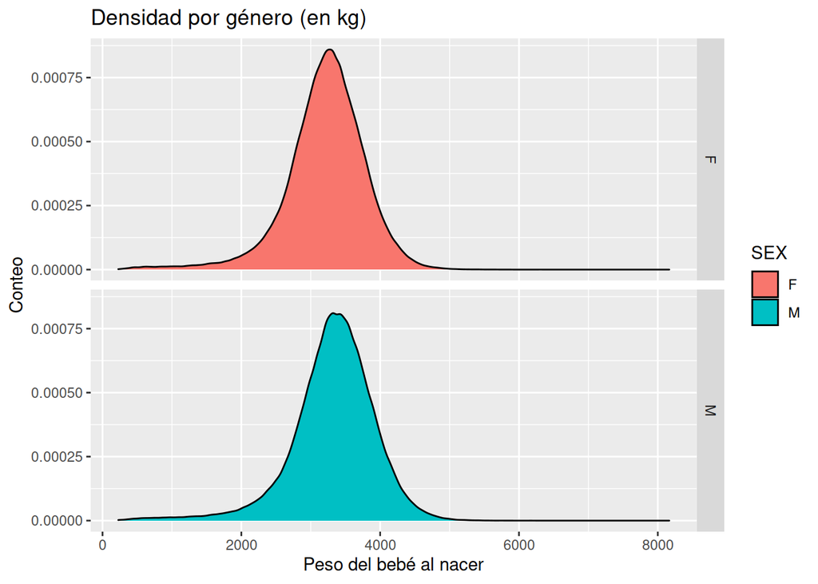

```r
# versión densidad
ggplot(data =  births2006.smpl, aes(DBWT, geom = "density", fill = SEX)) +
       geom_density() +
       facet_grid(SEX~.) +
labs(title="Densidad por género (en kg)",
      y = "Conteo",
      x = "Peso del bebé al nacer")
```

#### Boxplots

Los boxplots son útiles para comparación de datos agrupados o comparación de subpoblaciones:

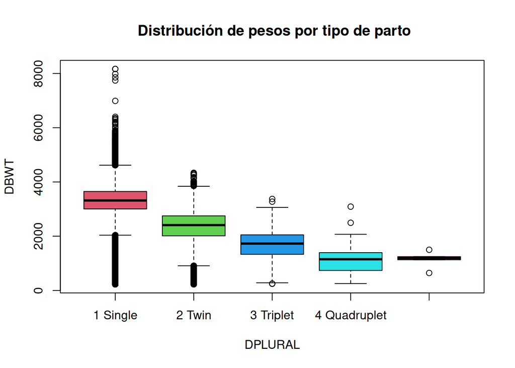

```r
boxplot(DBWT ~ DPLURAL, data = births2006.smpl, col =2:6,
        main = " Distribución de pesos por tipo de parto")
```

Versión ggplot2:

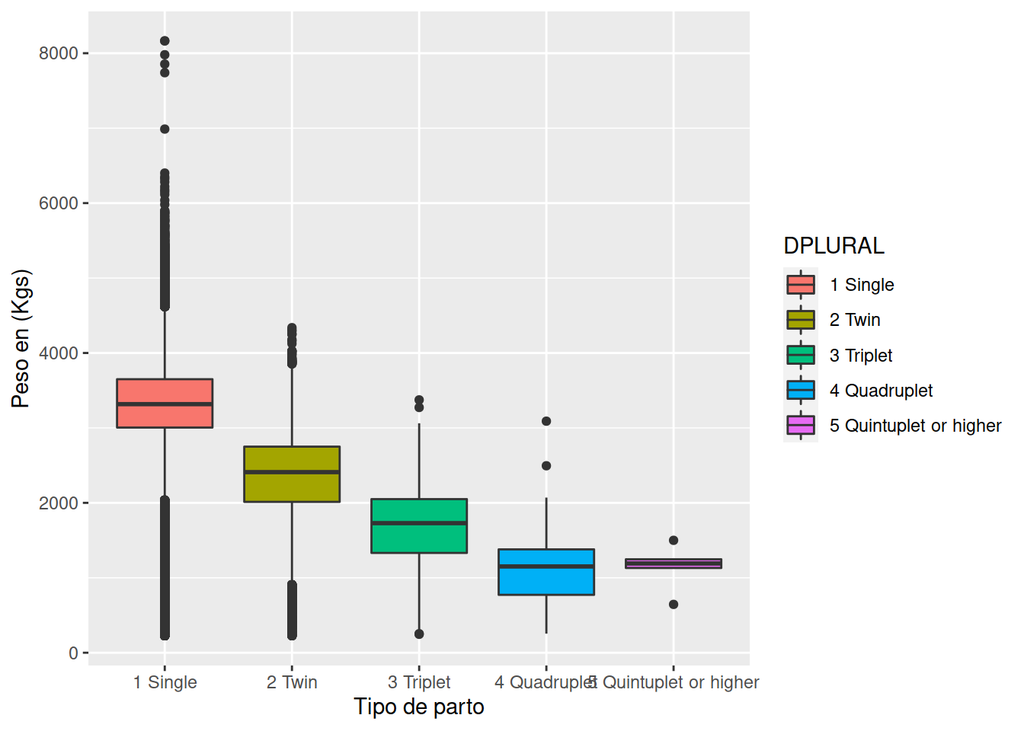

```r
ggplot(data = births2006.smpl, aes(x = DPLURAL, y = DBWT, fill = DPLURAL)) +
        geom_boxplot() +
        labs(y = "Peso en (Kgs)", x = "Tipo de parto")
```

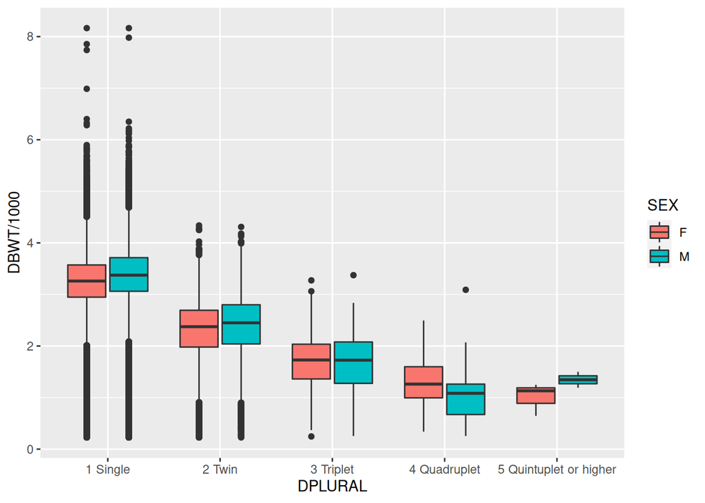

```r
# Podemos añadir otra variable para ver cambios en la distribución, por ejemplo, viendo el caso para
# nacimientos múltiples
ggplot(data = births2006.smpl, aes(x = DPLURAL, y = DBWT/1000, fill = SEX)) +
       geom_boxplot()  # También podemos considerar interacción SEX:DPLURAL
```

¿Cuáles son las conclusiones del análisis del peso de los bebés?

#### Nacimientos por día de la semana

La codificación comienza con domingo (1).

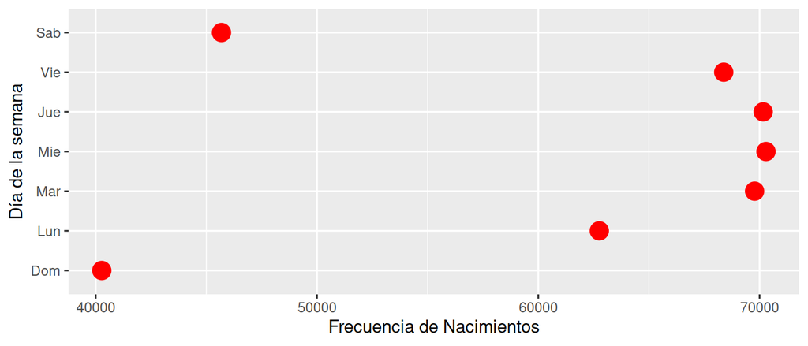

```r
births2006.smpl %>%
                group_by(DOB_WK) %>%
                summarize(Numero = n()) %>%
                ggplot(aes(x = DOB_WK, y = Numero)) +
                geom_point(color="red", fill="red4", size=5) +
                           labs(y = "Frecuencia de Nacimientos", x = "Día de la semana") +
                scale_x_discrete(limits=c("Dom", "Lun","Mar","Mie","Jue","Vie","Sab")) +
                           coord_flip()
```

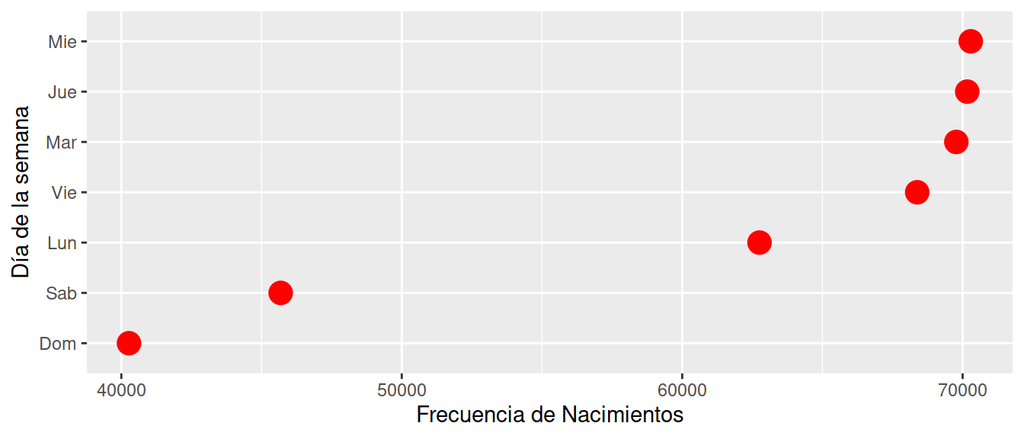

```r
# Con valores ordenados:

births2006.smpl %>%
                group_by(DOB_WK) %>%
                summarize(Numero = n()) %>%
                mutate(diasemana = factor(recode(DOB_WK,`1` = "Dom",
                                                        `2` = "Lun",
                                                        `3` = "Mar",
                                                        `4` = "Mie",
                                                        `5` = "Jue",
                                                        `6` = "Vie",
                                                        `7` = "Sab"))) %>%
                ggplot(aes(x = Numero, y= reorder(diasemana, Numero))) +
                geom_point(color="red", fill="red4", size=5) +
                           labs(x = "Frecuencia de Nacimientos", y = "Día de la semana")
```

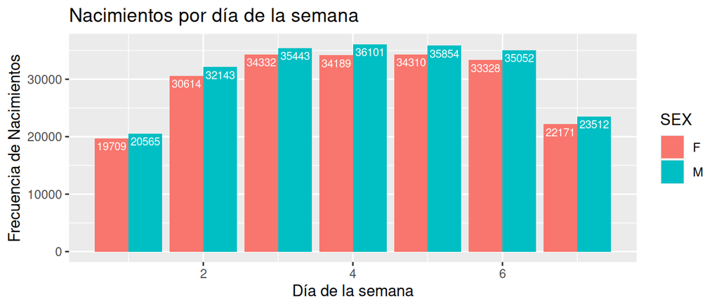

```r
# Otra opción:
births2006.smpl %>%
                group_by(DOB_WK,SEX) %>%
                summarize(Numero = n()) %>%
                ggplot(aes(x = DOB_WK, y = Numero, fill = SEX)) +
                  geom_bar(stat="identity",position = "dodge")  +
                  labs(y = "Frecuencia de Nacimientos", x = "Día de la semana",
                       title = "Nacimientos por día de la semana") +
                  geom_text(aes(label = Numero),
                            vjust = 1.5, color = "white",
                            position = position_dodge(.9), size = 2.7)
```

```r
tabla <- table(semana = births2006.smpl$DOB_WK,
               mes = births2006.smpl$DOB_MM)
tabla
```

```
      mes
semana    1    2    3    4    5    6    7    8    9   10   11   12
     1 3645 2930 2965 3616 2969 3036 3976 3160 3270 3964 2999 3744
     2 5649 4737 4779 4853 5712 5033 6263 5127 4850 6167 5043 4544
     3 6265 5293 5251 5297 6472 5178 5149 7225 5805 6887 5619 5334
     4 5131 5280 6486 5173 6496 5540 5499 7011 5725 5445 6838 5666
     5 5127 5271 6574 5162 5347 6863 5780 6945 5822 5538 6165 5570
     6 4830 5305 6330 5042 4975 6622 5760 5530 7027 5256 5079 6624
     7 3295 3392 3408 4185 3364 3464 4751 3686 4669 3564 3509 4396
```

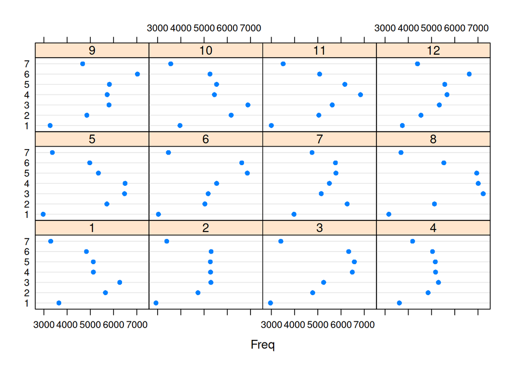

```r
dotplot(tabla, groups = F)
```

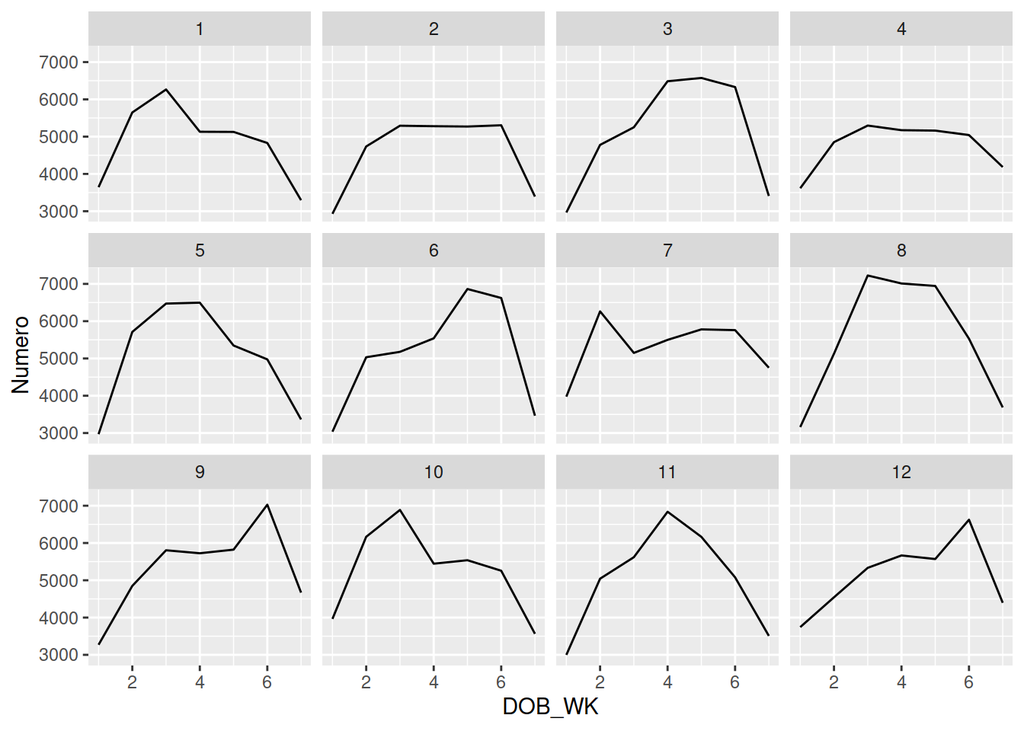

```r
# Otra versión con ggplot:
births2006.smpl %>%
   group_by(DOB_MM, DOB_WK) %>%
   summarise(Numero = n(),.groups = "drop") %>%
   ggplot(aes(x = DOB_WK, y = Numero)) +
   geom_line() +
   facet_wrap(. ~ DOB_MM)
```

### Por nacimientos múltiples

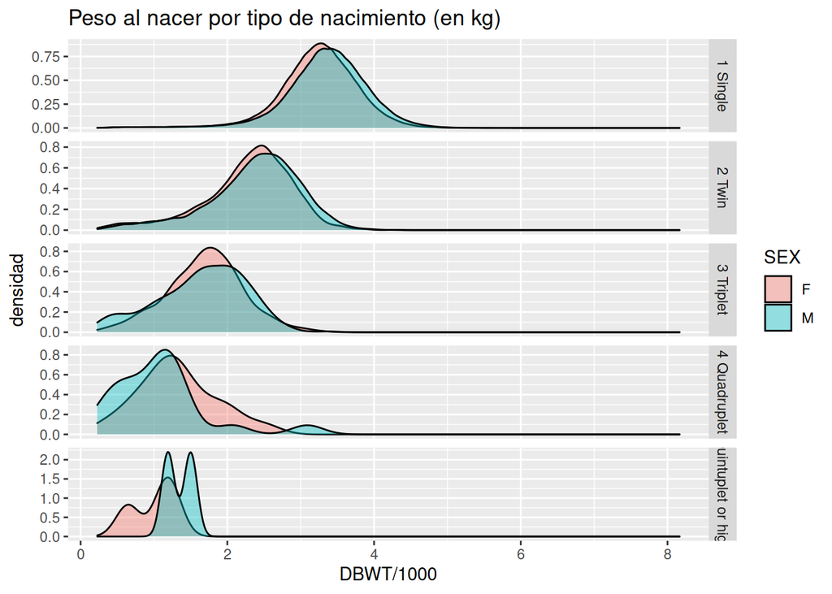

```r
ggplot(data = births2006.smpl, aes(DBWT/1000, fill = SEX)) +
       geom_density(alpha = 0.4) +
       facet_grid(DPLURAL~., scales = "free") +
       labs(y = "densidad", title = "Peso al nacer por tipo de nacimiento (en kg)")
```

### Relación entre edad, peso y nivel educativo de la madre con el peso del bebé

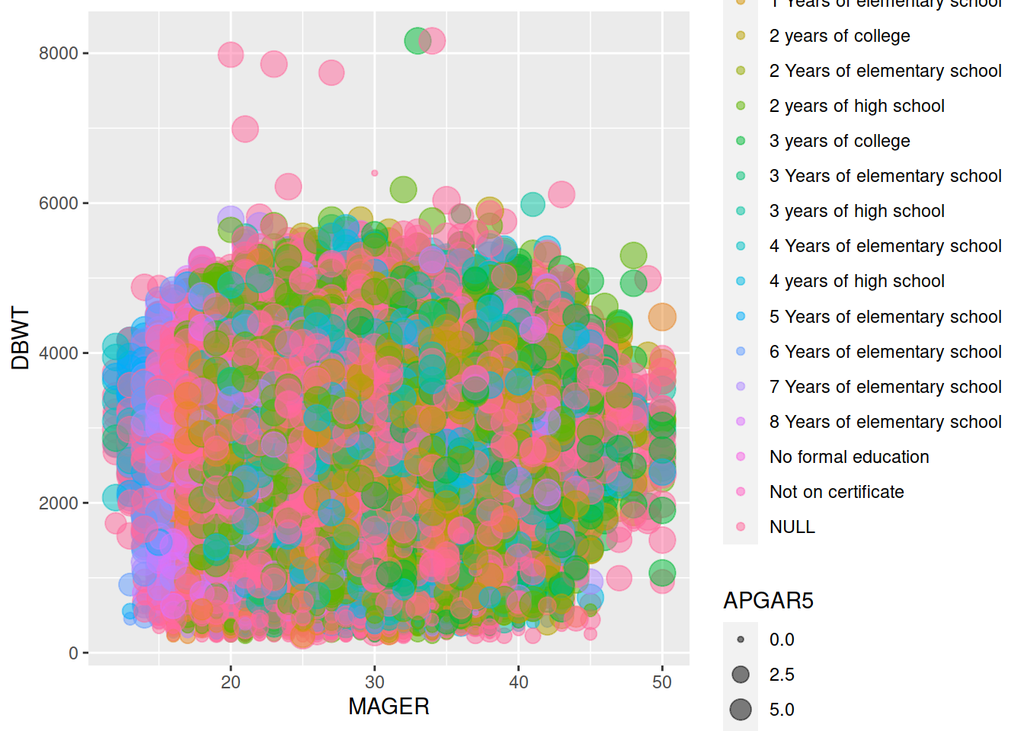

```r
births2006.smpl %>%
      select(MAGER, APGAR5, SEX, DBWT, DMEDUC) %>%
      ggplot(aes(x = MAGER, y = DBWT, col = DMEDUC, size = APGAR5)) +
      geom_point(alpha=0.5)
```

A veces los scatterplots son difíciles de interpretar cuando tienen muchos datos. Una opción es hacer algo similar a lo que hacemos con los histgramas, considerando *buckets* de los datos:

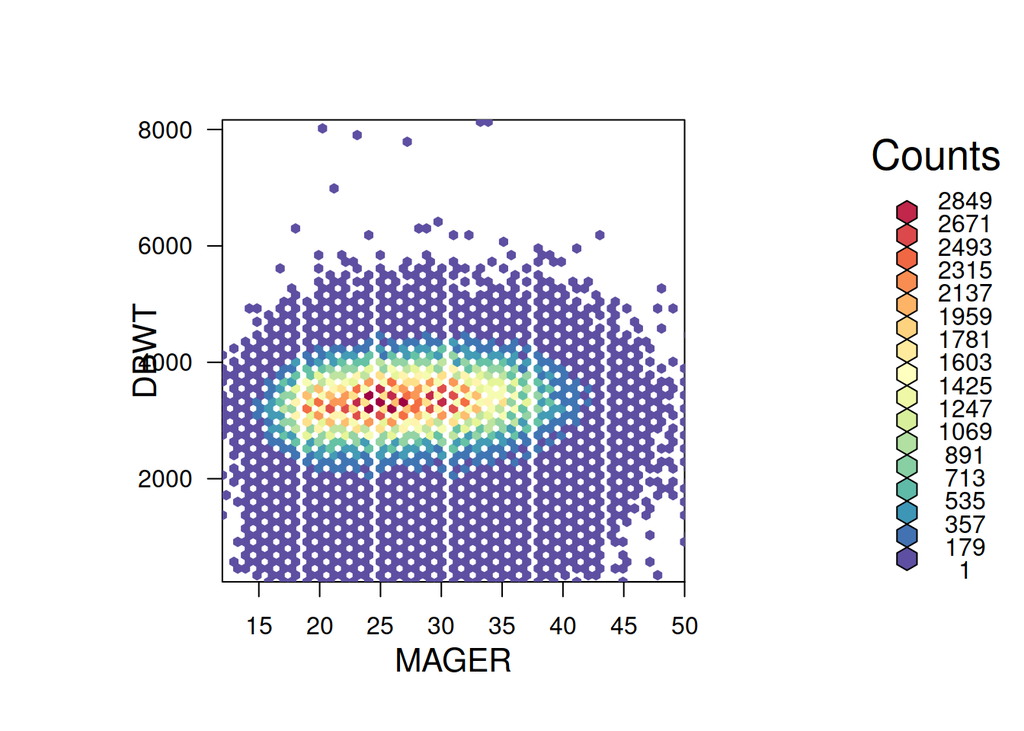

```r
library(hexbin)
library(RColorBrewer) # para paletas de colores

Z <- births2006.smpl %>%
       select(MAGER,DBWT)
bin <- hexbin(Z, xbins = 60)
colores <- colorRampPalette(rev(brewer.pal(11,"Spectral")))
plot(bin, colramp = colores)
```

Quizá sea más informativa la matriz de correlaciones

```r
a <- births2006.smpl %>% select(MAGER, APGAR5, DBWT, WTGAIN, UPREVIS, SEX) # subconjunto de variables
library(corrplot)
cor(a[,-6], use = "complete.obs")
```

```
              MAGER       APGAR5        DBWT      WTGAIN      UPREVIS
MAGER    1.00000000  0.010868881 0.072637212 -0.05514928  0.025375011
APGAR5   0.01086888  1.000000000 0.240483059  0.03209325 -0.006092428
DBWT     0.07263721  0.240483059 1.000000000  0.16712423  0.004842433
WTGAIN  -0.05514928  0.032093253 0.167124232  1.00000000  0.032161568
UPREVIS  0.02537501 -0.006092428 0.004842433  0.03216157  1.000000000
```

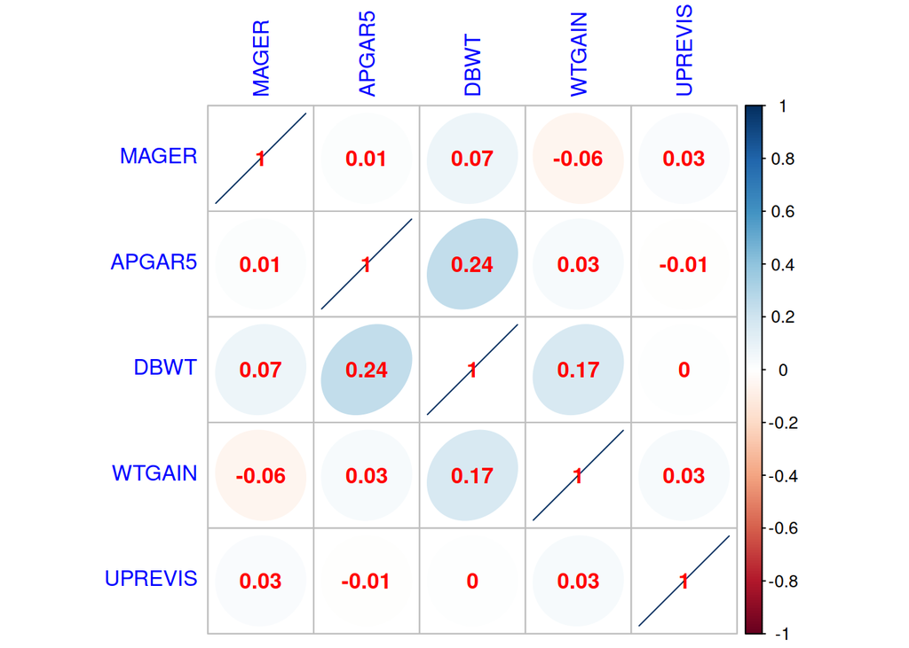

```r
corrplot(cor(a[,-6], use = "complete.obs"), is.corr = T,
         method = "ellipse", diag = T,  addCoefasPercent = F, tl.col = "blue", addCoef.col = "red")
```

### Diferentes tipos de gráficas con `GGally`

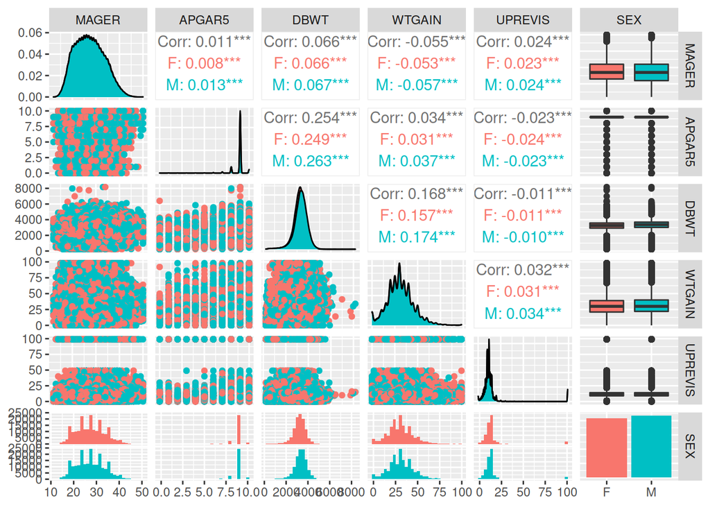

```r
library(GGally)
ggpairs(a, mapping = aes(color = SEX), )
```

Todavía quedan muchas preguntas que responder y subanálisis a hacer.

### Fuentes adicionales de información para exploración de datos

- [How Data Visualization was born](https://towardsdatascience.com/the-pioneers-of-data-visualization-ca58b7dc8013)
- paquete `codebook`

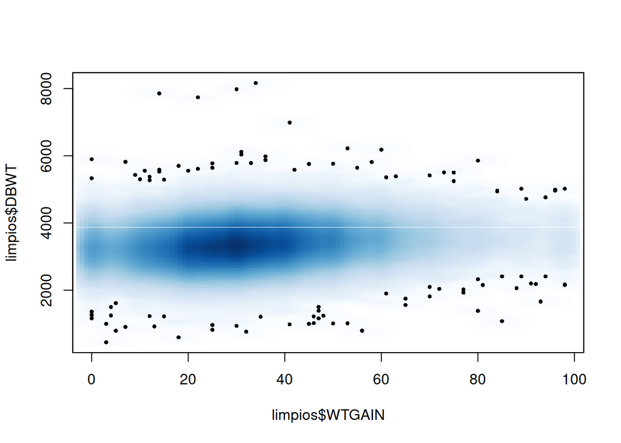

```r
# Consideramos la limpieza de datos para que la comparación sea adecuada
limpios <- births2006.smpl[!is.na(births2006.smpl$WTGAIN) &
                           !is.na(births2006.smpl$DBWT) &
                           births2006.smpl$DPLURAL == "1 Single" &
                           births2006.smpl$ESTGEST >35, ]
smoothScatter(limpios$WTGAIN, limpios$DBWT,pch = 16,cex=0.6)
```

[^1]: Los datos originales se pueden obtener de: [Vitalstatsonline](http://www.cdc.gov/nchs/data_access/Vitalstatsonline.htm) y el diccionario de datos está en la siguiente liga: Userguide2016.pdf. Los datos usados aquí corresponden al 10% de la muestra de datos originales. El archivo original tiene 3.1Gb.